# creditcard_fraud slides

## Erkennung von Kreditkartenbetrug

##### von Romeo, Marko, Nikola und Miro

## Intro

Wir trainieren ein Modell welches Credit Card Fraud erkennen Kann. Potenzieller Nutzer des Modells ist eine Bank. Der Input sind vergangene Transaktionen, diese enthalten unter anderem folgende Informationen: «median transaction value», «distance from home», distance from last transatction», «online transaction y/n» und weitere. Die einschätzung des Modells ist binär: «Kreditkartenbetrug / Kein Kreditkartenbetrug». Umsetzen werden wir das ganze in einem Classification Model. Eine Bank kann jede Kreditkartentransaktion mit unserem Modell abgleichen und so erkennen ob es Betrug ist oder nicht.

### Datenquelle

Die Daten für dieses Projekt stammen von Kaggle, einer Plattform für datenbasierte Wettbewerbe und Community-basiertes Data Science. Das genaue Datenset ist unter folgendem Link verfügbar: https://www.kaggle.com/datasets/dhanushnarayananr/credit-card-fraud. Es handelt sich um ein öffentlich zugängliches Datenset, das von einer nicht genannten Institution.  
Daten  
`card_transdata.csv` - die ganze Datenbank wurde bereitgestellt.

### Beschaffung der Daten

Die genaue Beschaffungsquelle für das Datenset wurde nicht angegeben. Es wird jedoch erwähnt, dass das Datenset von einer nicht genannten Institution bezogen wurde. Die Daten könnten beispielsweise von einer Bank, einem Zahlungsanbieter oder einem Forschungsinstitut stammen. Die genauen Umstände der Datenerhebung und die Einhaltung von Datenschutzbestimmungen sind nicht bekannt.

### Variablenbeschreibung

1. **distance_from_home:** Die Entfernung vom Ort des Karteninhabers, an dem die Transaktion stattgefunden hat.
2. **distance_from_last_transaction:** Die Entfernung zwischen der aktuellen Transaktion und der vorherigen Transaktion.
3. **ratio_to_median_purchase_price:** Das Verhältnis des Kaufpreises der aktuellen Transaktion zum Median des Kaufpreises aller Transaktionen.
4. **repeat_retailer:** Ein binärer Wert, der angibt, ob die Transaktion von demselben Einzelhändler wiederholt wurde.
5. **used_chip:** Ein binärer Wert, der angibt, ob bei der Transaktion der Chip der Kreditkarte verwendet wurde.
6. **used_pin_number:** Ein binärer Wert, der angibt, ob bei der Transaktion die PIN-Nummer der Kreditkarte verwendet wurde.
7. **online_order:** Ein binärer Wert, der angibt, ob die Transaktion eine Online-Bestellung war.
8. **fraud:** Ein binärer Wert, der angibt, ob die Transaktion als betrügerisch eingestuft wurde.

### Problem- und Fragestellung

Unser Problem besteht darin, Kreditkartenbetrug zu erkennen. Hierbei möchten wir ein Modell entwickeln, das Transaktionen analysiert und vorhersagt, ob eine Transaktion betrügerisch ist oder nicht. Die Fragestellung lautet daher: "Können wir anhand der verfügbaren Informationen einer Transaktion zuverlässig bestimmen, ob es sich um einen Kreditkartenbetrug handelt?"  
Zur Lösung dieses Problems werden wir ein maschinelles Lernmodell trainieren und evaluieren. Hierbei werden wir verschiedene Variablen, wie z.B. die Entfernung von zu Hause, die Art der Transaktion (Online oder Offline), die Verwendung des Chips und der PIN-Nummer, analysieren. Unser Ziel ist es, ein Modell zu entwickeln, das hohe Präzision und Genauigkeit bei der Erkennung von Kreditkartenbetrug aufweist.

**Fragestellung**:

1. Wie können wir mithilfe eines Modells Kreditkartenbetrug von legitimen Transaktionen unterscheiden?
2. Welche Merkmale und Muster in vergangenen Transaktionen können verwendet werden, um betrügerische Aktivitäten zu identifizieren?

### Zielsetzung

Unsere Zielsetzung besteht darin, ein Modell zur Erkennung von Kreditkartenbetrug zu entwickeln, das eine hohe Präzision und Genauigkeit aufweist. Konkret möchten wir folgende Ziele erreichen:

1. **Effektive Betrugserkennung:** Unser Hauptziel ist es, ein Modell zu entwickeln, das betrügerische Kreditkartentransaktionen zuverlässig erkennt. Wir wollen sicherstellen, dass das Modell eine hohe Genauigkeit bei der Identifizierung von betrügerischen Transaktionen erreicht und gleichzeitig falsche Alarme minimiert.
2. **Minimierung von Verlusten:** Durch die präzise Erkennung von Kreditkartenbetrug möchten wir dazu beitragen, finanzielle Verluste für Kreditkarteninhaber und Kreditkartenunternehmen zu minimieren. Indem wir betrügerische Transaktionen frühzeitig erkennen, können wir Maßnahmen ergreifen, um den Schaden zu begrenzen und die Auswirkungen auf die Betroffenen zu reduzieren.
3. **Verbesserung der Sicherheit:** Durch die Entwicklung eines effektiven Modells zur Kreditkartenbetrugserkennung wollen wir dazu beitragen, die Sicherheit von Kreditkartentransaktionen insgesamt zu verbessern. Indem wir betrügerische Aktivitäten erkennen und verhindern, schützen wir das Vertrauen der Verbraucher in den Einsatz von Kreditkarten und tragen zur Stärkung der gesamten Zahlungsbranche bei.
4. **Interpretierbarkeit des Modells:** Neben der Leistung des Modells ist es uns wichtig, die Entscheidungen des Modells interpretieren zu können. Wir streben an, die Beiträge der verschiedenen Variablen zur Modellvorhersage zu verstehen und Einblicke in die Merkmale und Muster von betrügerischen Transaktionen zu gewinnen. Dies ermöglicht es uns, unsere Erkenntnisse zu validieren und das Modell weiter zu verbessern.

### Vorgehen & Methoden

1. **Datenanalyse und Vorverarbeitung:** Analyse der Daten, Behandlung fehlender Werte, Transformation und Vorverarbeitung der Daten.
2. **Modellentwicklung:** Training und Evaluierung verschiedener maschineller Lernmodelle wie Random Forest, Logistische Regression oder Gradient Boosting zur Erkennung von Kreditkartenbetrug.
3. **Modelloptimierung:** Anwendung von Optimierungstechniken wie Hyperparameteranpassung, Feature-Engineering und Sampling-Methoden zur Verbesserung der Modellleistung.
4. **Modellbewertung:** Evaluierung der Modellleistung mit geeigneten Metriken wie Genauigkeit, Präzision, Recall und F1-Score.
5. **Interpretation des Modells:** Verwendung von Techniken wie SHAP, um die Entscheidungen des Modells zu interpretieren und Einblicke in die Muster von Kreditkartenbetrug zu gewinnen.

## Explorative Datenanalyse (EDA)

### Different Datatypes

```python
# Es wird angezeigt um welchen Wert-Typ es sich für die einzelnen Variablen im DataFrame handelt.
df.dtypes
```

```
distance_from_home                float64
distance_from_last_transaction    float64
ratio_to_median_purchase_price    float64
repeat_retailer                   float64
used_chip                         float64
used_pin_number                   float64
online_order                      float64
fraud                             float64
dtype: object
```

### Statistical measures (min, max, std, mean, median, count) for selected variables

```python
# von zwei verschiedenen Daten werden das Minimum, das Maximum, die Standardabweichung, der Median sowie die Anzahl berechnet
# Fraud
print('Fraud:',
      'Count:', round(df.fraud.count(), 1),
      'Min:', round(df.fraud.min(), 1),
      'Max:', round(df.fraud.max(), 1),
      'Mean:', round(df.fraud.mean(), 1),
      'Median:', round(df.fraud.median(), 1),
      'Std:', round(df.fraud.std(), 1))

# distance form home
print('distance from home:',
      'Count:', round(df.distance_from_home.count(), 1),
      'Min:', round(df.distance_from_home.min(), 1),
      'Max:', round(df.distance_from_home.max(), 1),
      'Mean:', round(df.distance_from_home.mean(), 1),
      'Median:', round(df.distance_from_home.median(), 1),
      'Std:', round(df.distance_from_home.std(), 1))
```

```
Fraud: Count: 1000000 Min: 0.0 Max: 1.0 Mean: 0.1 Median: 0.0 Std: 0.3
distance from home: Count: 1000000 Min: 0.0 Max: 10632.7 Mean: 26.6 Median: 10.0 Std: 65.4
```

### Skewness

```python
# die Schiefe der Verteilung für jedes Merkmal im DataFrame wird berechnet
df.skew()
```

```
distance_from_home                 20.239733
distance_from_last_transaction    125.921226
ratio_to_median_purchase_price      8.915015
repeat_retailer                    -2.361310
used_chip                           0.627134
used_pin_number                     2.655457
online_order                       -0.631517
fraud                               2.921824
dtype: float64
```

### Kurtousis

```python
# die Kurtosis (Wölbung) der Verteilung wrid für jedes Merkmal im DataFrame berechnet
df.kurtosis()
```

```
distance_from_home                 1471.615654
distance_from_last_transaction    46979.271728
ratio_to_median_purchase_price      289.503307
repeat_retailer                       3.575791
used_chip                            -1.606706
used_pin_number                       5.051461
online_order                         -1.601190
fraud                                 6.537067
dtype: float64
```

### Extreme values

```python
# Extremwerte die über/unter sein können werden festgelegt
# Long Distance from home
df[df.distance_from_home <= 15].head()
```

|  | distance_from_home | distance_from_last_transaction | ratio_to_median_purchase_price | repeat_retailer | used_chip | used_pin_number | online_order | fraud |
| --- | --- | --- | --- | --- | --- | --- | --- | --- |
| 1 | 10.829943 | 0.175592 | 1.294219 | 1.0 | 0.0 | 0.0 | 0.0 | 0.0 |
| 2 | 5.091079 | 0.805153 | 0.427715 | 1.0 | 0.0 | 0.0 | 1.0 | 0.0 |
| 3 | 2.247564 | 5.600044 | 0.362663 | 1.0 | 1.0 | 0.0 | 1.0 | 0.0 |
| 5 | 5.586408 | 13.261073 | 0.064768 | 1.0 | 0.0 | 0.0 | 0.0 | 0.0 |
| 6 | 3.724019 | 0.956838 | 0.278465 | 1.0 | 0.0 | 0.0 | 1.0 | 0.0 |

```python
# Short distance from last transaction
df[df.distance_from_last_transaction < 0.5].head()
```

|  | distance_from_home | distance_from_last_transaction | ratio_to_median_purchase_price | repeat_retailer | used_chip | used_pin_number | online_order | fraud |
| --- | --- | --- | --- | --- | --- | --- | --- | --- |
| 0 | 57.877857 | 0.311140 | 1.945940 | 1.0 | 1.0 | 0.0 | 0.0 | 0.0 |
| 1 | 10.829943 | 0.175592 | 1.294219 | 1.0 | 0.0 | 0.0 | 0.0 | 0.0 |
| 7 | 4.848247 | 0.320735 | 1.273050 | 1.0 | 0.0 | 1.0 | 0.0 | 0.0 |
| 10 | 14.263530 | 0.158758 | 1.136102 | 1.0 | 1.0 | 0.0 | 1.0 | 0.0 |
| 11 | 13.592368 | 0.240540 | 1.370330 | 1.0 | 1.0 | 0.0 | 1.0 | 0.0 |

## Multivariate non-graphical exploratory data analysis (EDA)

### Cross-tabulation

```python
# erstellt eine Kreuztabelle zwischen den zwei definierten Spalten im DataFrame
# Es ist eine nützliche Methode, um die Beziehung zwischen zwei kategorialen Variablen zu analysieren
pd.crosstab(df['distance_from_home'], df['fraud'])
```

| fraud distance_from_home | 0.0 | 1.0 |
| --- | --- | --- |
| 0.004874 | 1 | 0 |
| 0.021322 | 1 | 0 |
| 0.022599 | 1 | 0 |
| 0.024144 | 1 | 0 |
| 0.024461 | 1 | 0 |
| ... | ... | ... |
| 4601.011222 | 1 | 0 |
| 4823.638452 | 1 | 0 |
| 5797.972589 | 1 | 0 |
| 8777.136420 | 1 | 0 |
| 10632.723672 | 0 | 1 |

1000000 rows × 2 columns

### Pivot tables

```python
# Der Durchschnitt zweier Werte wird genommen und nach einem Dritten Wert gruppiert
# Gut geeignet um Daten beser zu analysieren und verstehen
# Using pivot_table to reshape the data and calculate means
pd.pivot_table(df[['fraud', 'distance_from_home', 'ratio_to_median_purchase_price']],
               index=['fraud'],
               values=['distance_from_home', 'ratio_to_median_purchase_price'],
               aggfunc=np.mean)
```

| fraud | distance_from_home | ratio_to_median_purchase_price |
| --- | --- | --- |
| 0.0 | 22.832976 | 1.423642 |
| 1.0 | 66.261876 | 6.006323 |

### Correlation matrix

```python
# Die Korrelationsmatrix ist eine Tabelle, die die Korrelationskoeffizienten zwischen vielen Variablen darstellt
# Jeder Zellenwert stellt die Korrelation zwischen zwei Variablen dar
corr = df.corr()
corr
```

|  | distance_from_home | distance_from_last_transaction | ratio_to_median_purchase_price | repeat_retailer | used_chip | used_pin_number | online_order | fraud |
| --- | --- | --- | --- | --- | --- | --- | --- | --- |
| distance_from_home | 1.000000 | 0.000193 | -0.001374 | 0.143124 | -0.000697 | -0.001622 | -0.001301 | 0.187571 |
| distance_from_last_transaction | 0.000193 | 1.000000 | 0.001013 | -0.000928 | 0.002055 | -0.000899 | 0.000141 | 0.091917 |
| ratio_to_median_purchase_price | -0.001374 | 0.001013 | 1.000000 | 0.001374 | 0.000587 | 0.000942 | -0.000330 | 0.462305 |
| repeat_retailer | 0.143124 | -0.000928 | 0.001374 | 1.000000 | -0.001345 | -0.000417 | -0.000532 | -0.001357 |
| used_chip | -0.000697 | 0.002055 | 0.000587 | -0.001345 | 1.000000 | -0.001393 | -0.000219 | -0.060975 |
| used_pin_number | -0.001622 | -0.000899 | 0.000942 | -0.000417 | -0.001393 | 1.000000 | -0.000291 | -0.100293 |
| online_order | -0.001301 | 0.000141 | -0.000330 | -0.000532 | -0.000219 | -0.000291 | 1.000000 | 0.191973 |
| fraud | 0.187571 | 0.091917 | 0.462305 | -0.001357 | -0.060975 | -0.100293 | 0.191973 | 1.000000 |

### Covariance matrix

```python
# Die Kovarianz misst das gemeinsame Streuungsmass von zwei Variablen
cov = df.cov()
cov
```

|  | distance_from_home | distance_from_last_transaction | ratio_to_median_purchase_price | repeat_retailer | used_chip | used_pin_number | online_order | fraud |
| --- | --- | --- | --- | --- | --- | --- | --- | --- |
| distance_from_home | 4275.954684 | 0.325861 | -0.251567 | 3.024428 | -0.021747 | -0.031909 | -0.040567 | 3.464054 |
| distance_from_last_transaction | 0.325861 | 667.865469 | 0.073256 | -0.007752 | 0.025336 | -0.006986 | 0.001736 | 0.670877 |
| ratio_to_median_purchase_price | -0.251567 | 0.073256 | 7.837698 | 0.001243 | 0.000783 | 0.000793 | -0.000440 | 0.365532 |
| repeat_retailer | 3.024428 | -0.007752 | 0.001243 | 0.104430 | -0.000207 | -0.000041 | -0.000082 | -0.000124 |
| used_chip | -0.021747 | 0.025336 | 0.000783 | -0.000207 | 0.227620 | -0.000200 | -0.000050 | -0.008216 |
| used_pin_number | -0.031909 | -0.006986 | 0.000793 | -0.000041 | -0.000200 | 0.090486 | -0.000042 | -0.008520 |
| online_order | -0.040567 | 0.001736 | -0.000440 | -0.000082 | -0.000050 | -0.000042 | 0.227334 | 0.025851 |
| fraud | 3.464054 | 0.670877 | 0.365532 | -0.000124 | -0.008216 | -0.008520 | 0.025851 | 0.079764 |

## Univariate graphical exploratory data analysis (EDA)

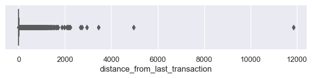

```python
# Ein Boxplot für die bestimmte Variable wird erzeugt
plt.figure(figsize=(8,1.2))
plt.ticklabel_format(style='plain')
sns.boxplot(x=df['distance_from_last_transaction'], color="greenyellow")
```

### Histogram (matplotlib)

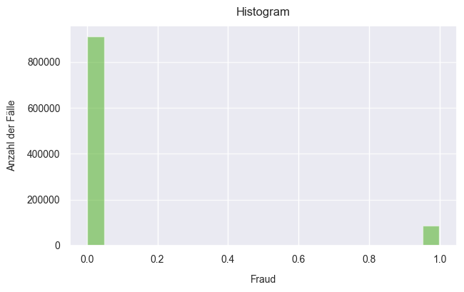

```python
# Für die definierte Variable wird ein Histogramm erzeugt
# Es ist ein effektiver Weg, um die grundlegende Struktur und die Muster in den Daten zu verstehen
# Sachen wie Streuung, Schiefe und Kurtosis sind ersichtbar
# Plot Histogram
fig = plt.figure( figsize=(7,4))
plt.xticks(fontsize=14, rotation=0)
plt.yticks(fontsize=14, rotation=0)
n, bins, patches = plt.hist(x=df['fraud'],
                            bins=20,
                            color='#42AD12',
                            alpha=0.5,
                            rwidth=0.95
                   )
plt.grid(True)
plt.ticklabel_format(style='plain')
plt.grid(axis='y', alpha=0.75)

# Set labels
plt.xlabel('Fraud', fontsize=10, labelpad=10)
plt.ylabel('Anzahl der Fälle', fontsize=10, labelpad=10)
plt.title('Histogram', fontsize=12, pad=10)

# Set fontsize of tick labels
plt.xticks(fontsize = 10)
plt.yticks(fontsize = 10)

plt.show()
```

### Density plot (seaborn)

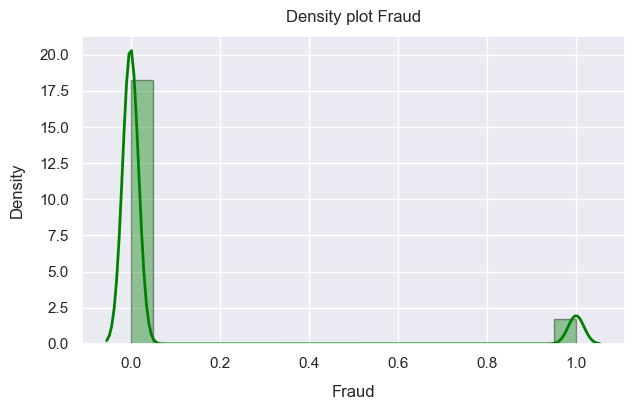

```python
# Technik zur Visualisierung der Verteilung einer kontinuierlichen oder numerischen Datenvariablen
# Es ähnelt einem Histogramm, da es die Verteilung der Daten visualisiert
# im Gegensatz zu einem Histogramm, das eine diskrete Darstellung liefert, bietet ein Dichtediagramm eine kontinuierliche Darstellung der Daten.
plt.figure(figsize=(7,4))
sns.distplot(df['fraud'],
             hist=True,
             kde=True,
             bins=20,
             color = 'green',
             hist_kws={'edgecolor':'black'},
             kde_kws={'linewidth': 2},
            )
plt.title('Density plot Fraud', fontsize=12, pad=10)
plt.xlabel('Fraud', fontsize=12, labelpad=10)
plt.ylabel('Density', fontsize=12, labelpad=10)
plt.grid(True)
plt.show()
```

### Quantile-Quantile (QQ-) plot

```
        ratio_to_median_purchase_price        var
124668                        0.004399  -0.650018
283731                        0.005741  -0.649539
572589                        0.006125  -0.649401
940935                        0.007278  -0.648990
934621                        0.007370  -0.648957
...                                ...        ...
997803                      126.713701  44.609949
956807                      146.213898  51.575328
280129                      168.137909  59.406482
88431                       266.689692  94.608716
470542                      267.802942  95.006363

[1000000 rows x 2 columns]
```

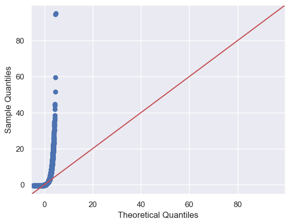

```python
# nützliches Werkzeug zur visuellen Prüfung, ob Daten einer bestimmten theoretischen Verteilung folgen
# in diesem Fall folgt der QQ-Plot der Normalverteilung
# Variable (standardized)
x = 'ratio_to_median_purchase_price'
df_qq = df
df_qq['var'] = (df[x]-df[x].mean()) / df[x].std()
print(df_qq.sort_values('var')[['ratio_to_median_purchase_price', 'var']])

# Plot
sm.qqplot(df_qq['var'], line ='45')
py.show()
```

### Piechart (matplotlib)

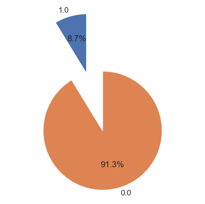

```python
# Stellt in einem Kuchendiagramm die Verteilung der Werte einer Variable an
df_bar = df.fraud.value_counts().nlargest(8).sort_values(ascending=True)

# Simple bar chart
sizes = list(df_bar.values)
labels = list(df_bar.index.values)
explode = (0,1) # increases distance of pieces

fig1, ax1 = plt.subplots(figsize=(5,5))
ax1.pie(sizes,
        labels=labels,
        explode=explode,
        autopct='%1.1f%%',
        shadow=False,
        startangle=90)
ax1.axis('equal')  # ensures that pie is drawn as a circle.

plt.show()
```

## Multivariate graphical exploratory data analysis (EDA)

### Scatterplot (matplotlib)

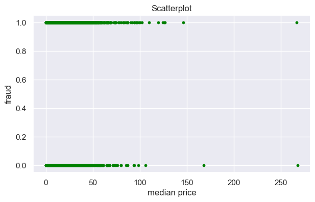

```python
# erstellt ein Scatterplot, das die Beziehung zwischen zwei bestimmten Variablen im DataFrame darstellt
# kann nützlich sein, um Muster, Trends oder Ausreißer in den Daten zu erkennen
plt.figure(figsize=(7,4))
plt.scatter(df['ratio_to_median_purchase_price'],
           df['fraud'],
           color="green",
           alpha=1.0,
           s=10)
plt.title('Scatterplot', fontsize=12)
plt.xlabel('median price')
plt.ylabel('fraud')
plt.show()
```

### Scatterplot (matplotlib) with regression line

```
(1000000, 9)
0.04663768362531651
0.0023273780161673437
```

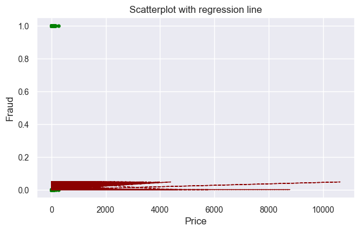

```python
# genau gleich wie der obere Scatterplot
# Eine Regressionslinie wird ebenfalls gezeichnet, um den Trend in den Daten darzustellen

# Subset
df_sub = df.loc[(df.fraud >= 0)]
print(df_sub.shape)

# Scatterplot
plt.figure(figsize=(7,4))
plt.plot(df_sub.ratio_to_median_purchase_price,
         df_sub.fraud,
         'o',
         markersize=3.5,
         color="green")

# Regression line (b = slope, a=intercept)
b, a = np.polyfit(df_sub.ratio_to_median_purchase_price, df_sub.fraud, 1)
print(b)
print(a)

# Plot regression line
plt.plot(df_sub.distance_from_home,
         b*df_sub.fraud + a,
         linewidth=1,
         linestyle='dashed',
         color='darkred')

# Add title and axes labels
plt.title('Scatterplot with regression line', fontsize=12)
plt.ylabel('Fraud', fontsize=12)
plt.xlabel('Price', fontsize=12)

# Set fontsize of tick labels
plt.xticks(fontsize = 10)
plt.yticks(fontsize = 10)

plt.show()
```

### Scatterplot-matrix (seaborn)

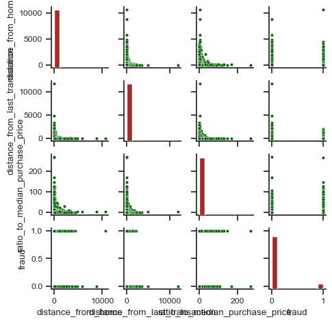

```python
# erstellt ein PairGrid, das ist eine Matrix von Scatterplots, die jede Kombination von Variablenpaaren in einem DataFrame darstell
sns.set(style="ticks", font_scale=0.8)
g = sns.PairGrid(df[['distance_from_home',
                     'distance_from_last_transaction',
                     'ratio_to_median_purchase_price',
                     'fraud']],
                 height=1.2,
                 aspect=1)
g.map_upper(sns.scatterplot,color='darkgreen', s=10)
g.map_lower(sns.scatterplot, color='darkgreen', s=10)
g.map_diag(plt.hist, color='brown')
```

### Hexagonal binning plot (matplotlib)

```
(46281, 9)
```

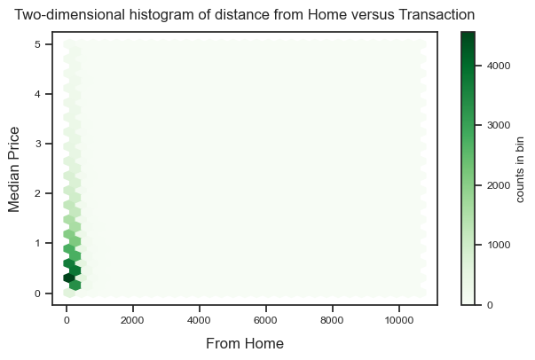

```python
# alternative Methode zur Darstellung von zweidimensionalen Histogrammen
# besonders nützlich, wenn man eine grosse Menge an Punkten darstellen muss
# besser als wenn normale Scatterplots zu dicht oder überlappend werden würden, um nützlich zu sein
# Subset
df_sub = df.loc[(df.distance_from_home >= 100) & (df.ratio_to_median_purchase_price <= 5)]
print(df_sub.shape)

# Plot
fig = plt.figure( figsize=(7,4) )
plt.hexbin(df_sub.distance_from_home, df_sub.ratio_to_median_purchase_price, gridsize=30, cmap='Greens')

# Set labels
plt.xlabel('From Home', fontsize=12, labelpad=10)
plt.ylabel('Median Price', fontsize=12, labelpad=10)
plt.title('Two-dimensional histogram of distance from Home versus Transaction', fontsize=12, pad=10)

cb = plt.colorbar(label='count in bin')
cb.set_label('counts in bin')
```

### Scatterplot der mehrere Merkmale visualisiert

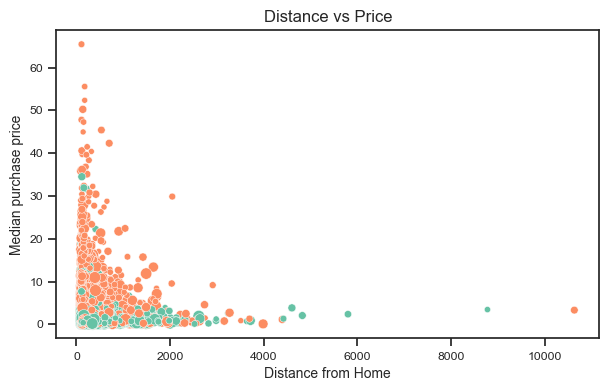

```python
# Farbe bestimmt ob es sich um einen Betrugsfall handelt
# Bubble grösse bestimmt wie lange die Transaktion her ist
# Subset of df
df_sub = df.loc[(df['distance_from_home'] >= 100) & (df['distance_from_last_transaction'] <= 5)]

plt.figure(figsize=(7,4))
plt.ticklabel_format(style='plain')
cmap = sns.cubehelix_palette(dark=.3, light=3, as_cmap=True)

ax = sns.scatterplot(x="distance_from_home",
                     y="ratio_to_median_purchase_price",
                     size="distance_from_last_transaction", # determines bubble size
                     hue="fraud",  # determines color
                     palette="Set2",
                     data=df_sub)

# Set title and axes
ax.set_title('Distance vs Price', fontsize = 12)
ax.set_xlabel('Distance from Home', fontsize = 10)
ax.set_ylabel('Median purchase price', fontsize = 10)
ax.legend([],[], frameon=False) # skip legend
```